# **Analysis of Barbie (2023) IMDB’s Reviews**

## **Data Sources**

#### **Reference**

Ibrahim (2023, August 3) IMDB Reviews on Barbie. *Kaggle*. https://www.kaggle.com/datasets/ibrahimonmars/imdb-reviews-on-barbie

## **Analytics**

### **Data Cleaning**

Here are all of the library used for this project

```r
library(tidyverse)
library(stringr)
library(scales)
library(tidytext)
library(textstem)
```

```r
library(tidyr)
library(ggwordcloud)
library(treemapify)
library(vader)
library(reshape2)
library(igraph)
library(ggraph)
library(forcats)
library(topicmodels)
```

Let’s load up the data.

```r
dat <- fst::read_fst("Barbie.fst")
glimpse(dat)
```

```
## Rows: 797
## Columns: 2
## $ text   <chr> "Beautiful film, but so preachyLoveofLegacy21 July 2023Margot d…
## $ rating <chr> "6", "6", "8", "9", "7", "8", "6", "8", "6", "8", "6", "4", "1"…
```

I assigned a unique ID for each review for the convient of spliting and joining data back together. Regular expressions (regex) were utilized to (1) extract date and (2) remove introduction and username

```r
dat$ID <- 1:length(dat$text) #Assigning ID

dat$date <- mark::str_extract_date(dat$text, format = "%d %B %Y") #extract date
dat$thesisUsername <- stringr::str_extract(dat$text, "^\\D+") #split username and excerpt from the full review

dat$rating <- as.numeric(dat$rating) #convert rating to numeric since a couple of them has lettering rating for some reason. These will become NA
```

```
## Warning: NAs introduced by coercion
```

```r
glimpse(dat)
```

```
## Rows: 797
## Columns: 5
## $ text           <chr> "Beautiful film, but so preachyLoveofLegacy21 July 2023…
## $ rating         <dbl> 6, 6, 8, 9, 7, 8, 6, 8, 6, 8, 6, 4, 1, 8, 6, 8, 6, NA, …
## $ ID             <int> 1, 2, 3, 4, 5, 6, 7, 8, 9, 10, 11, 12, 13, 14, 15, 16, …
## $ date           <date> 2023-07-21, 2023-07-21, 2023-07-24, 2023-07-24, 2023-0…
## $ thesisUsername <chr> "Beautiful film, but so preachyLoveofLegacy", "Clever a…
```

I exported the data, manually go through all reviews to delete the username from the excerpt not knowing that I would not even analyze them. Additionally, str_extract_date missed some of the date so I utilized this chance to fix them. This data is then saved to *BarbieScrub*

During this process, I discovered that the scraper did not account for spoiler reviews which is hidden behind the label of “Warning: Spoilers”. There were other noise texts as well such as “Click here to sign up” and so on. I am inexperienced with regex and so wasn’t able to remove all of these noises. Fortunately, the left over noise did not affect the analysis.

```r
dat <- fst::read_fst("BarbieScrub.fst") #Load data

noSpoiler <- dat %>% filter(!grepl("Warning: Spoilers", text)) #Remove spoiler reviews
noSpoiler$review <- sub('.*July 2023', '', noSpoiler$text) #Failed attempt at removing "x out of x find this helpful"
noSpoiler <- noSpoiler %>% subset(select = -c(text, thesis, rating, date)) #remove some columns

glimpse(noSpoiler)
```

```
## Rows: 600
## Columns: 2
## $ ID     <dbl> 1, 2, 4, 6, 8, 9, 10, 13, 14, 15, 16, 18, 19, 22, 24, 25, 26, 2…
## $ review <chr> "Margot does the best with what she's given, but this film was …
```

I loaded up the stop-word and afinn sentiment libraries in preparation for text analysis

```r
data("stop_words")
afinn <- get_sentiments("afinn")

paste("Stop-words Library")
```

```
## [1] "Stop-words Library"
```

```r
glimpse(stop_words)
```

```
## Rows: 1,149
## Columns: 2
## $ word    <chr> "a", "a's", "able", "about", "above", "according", "accordingl…
## $ lexicon <chr> "SMART", "SMART", "SMART", "SMART", "SMART", "SMART", "SMART",…
```

```r
paste("AFINN Library")
```

```
## [1] "AFINN Library"
```

```r
glimpse(afinn)
```

```
## Rows: 2,477
## Columns: 2
## $ word  <chr> "abandon", "abandoned", "abandons", "abducted", "abduction", "ab…
## $ value <dbl> -2, -2, -2, -2, -2, -2, -3, -3, -3, -3, 2, 2, 1, -1, -1, 2, 2, 2…
```

### **Analysis**

```r
tidyDat <- noSpoiler %>% unnest_tokens(word, review) #tokenization

tidyDat <- tidyDat %>% anti_join(stop_words) #removing stop-words
tidyDat$word <- tidyDat$word %>% str_to_lower(locale = "en") #convert all strings to lower cases
tidyDat$word <- lemmatize_words(tidyDat$word) #lemmatization

wordCount <- tidyDat %>% count(word, sort = T) #Get word count
glimpse(wordCount)
```

```
## Rows: 7,179
## Columns: 2
## $ word <chr> "movie", "barbie", "film", "world", "woman", "ken", "watch", "fun…
## $ n    <int> 1882, 1558, 920, 460, 440, 409, 379, 371, 326, 309, 299, 290, 277…
```

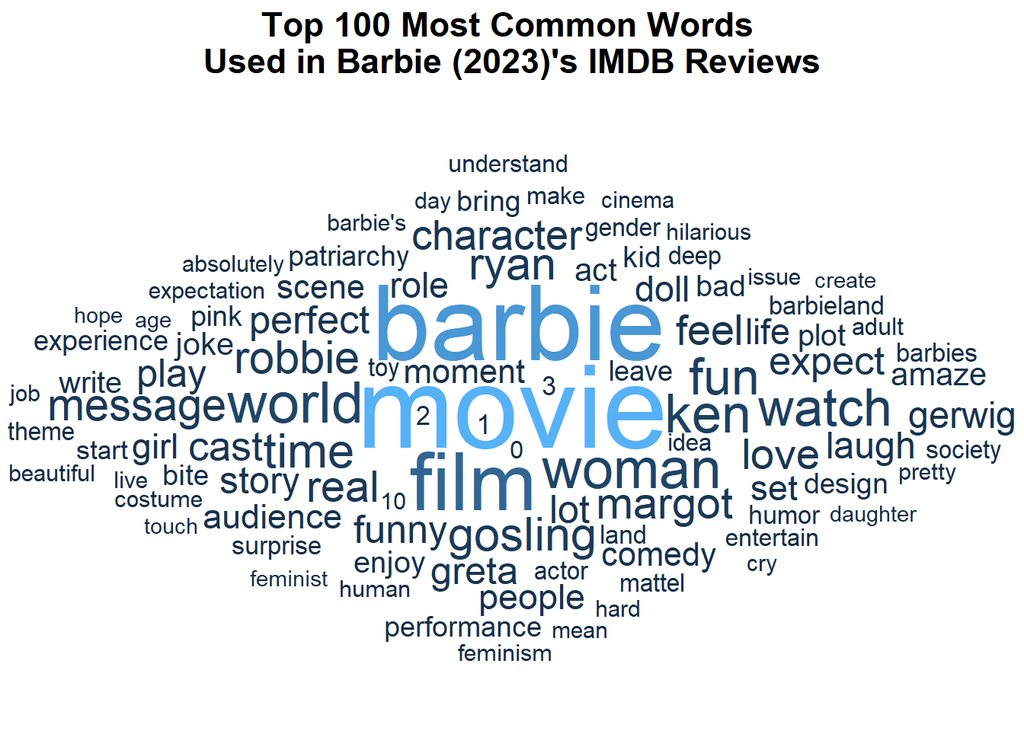

```r
wordCount %>%
        head(100) %>%
        ggplot(., aes(label = word, size = n, color = n))+
        geom_text_wordcloud(shape = "diamond")+
        scale_size_area(max_size = 20)+
        theme_void()+
        theme(text = element_text(size = 14, face = "bold"),
              plot.title = element_text(hjust = .5))+
  labs(title = "Top 100 Most Common Words \nUsed in Barbie (2023)'s IMDB Reviews")
```

[figure not shown]

```r
wordCount %>% head(100) %>%
  ggplot(., aes(area = n, fill = n,
                label = paste(word, "\ncount:", n)))+
  geom_treemap()+
  geom_treemap_text(place = "centre")+
  theme(text = element_text(size = 14, face = "bold"),
              plot.title = element_text(hjust = .5),
        legend.position = "none")+
  labs(title = "Top 100 Most Common Words \nUsed in Barbie (2023)'s IMDB Reviews")
```

##### Bi-gram Count

Preparation is similar to word count

```r
#Tokenization
bi_gram <- noSpoiler %>%
  unnest_tokens(bigram, review, token = "ngrams", n = 2) %>%
  filter(!is.na(bigram))

#All to lowercase
bi_gram$bigram <- str_to_lower(bi_gram$bigram, locale = "en")

#Remove stop-word
bigrams_separated <- bi_gram %>%
  separate(bigram, c("word1", "word2"), sep = " ")

bigrams_filtered <- bigrams_separated %>%
  filter(!word1 %in% stop_words$word) %>%
  filter(!word2 %in% stop_words$word)

bigrams_filtered$word1 <- lemmatize_words(bigrams_filtered$word1)
bigrams_filtered$word2 <- lemmatize_words(bigrams_filtered$word2)

#Word Count
bigram_counts <- bigrams_filtered %>%
  count(word1, word2, sort = TRUE)

bigram_counts$word12 <- str_c(bigram_counts$word1, " ", bigram_counts$word2) #Join data back
```

Bi-gram frequency shows a heavier emphasis on cast member names and movie summary which is not quite helpful. One bi-gram of note is “social commentary” which is indeed one of the objectives of the movie.

[figure not shown]

```r
bigram_counts %>%
  head(100) %>%
  ggplot(., aes(label = word12, size = n, color = n))+
  geom_text_wordcloud(shape = "diamond")+
  theme_minimal()+
  scale_color_gradient(low = "darkgreen", high = "lightgreen")+
  scale_size_area(max_size = 12)+
  theme(text = element_text(size = 14, face = "bold"),
              plot.title = element_text(hjust = .5))+
  labs(title = "Top 100 Most Common Bi-Grams \nUsed in Barbie (2023)'s IMDB Reviews")
```

[figure not shown]

```r
bigram_counts %>% head(100) %>%
  ggplot(., aes(area = n, fill = n,
                label = paste(word12, "\ncount:", n)))+
  geom_treemap()+
  scale_fill_gradient(low = "darkgreen", high = "lightgreen")+
  geom_treemap_text(place = "centre")+
  theme(text = element_text(size = 14, face = "bold"),
              plot.title = element_text(hjust = .5),
        legend.position = "none")+
  labs(title = "Top 100 Most Common Bi-Grams \nUsed in Barbie (2023)'s IMDB Reviews")
```

#### *Sentiment Analysis*

##### Word Sentiment

Preparation is pretty simple, I join the dataset with the afinn library, which sentiment is code on a numeric scale, and then assign sentiment labels (i.e., positive, negative) based on whether a number is negative or not. Then it is just a matter of getting the word count.

```r
wordSent <- inner_join(tidyDat, afinn)
wordSent <- wordSent %>% group_by(word, value) %>% summarise (n = n()) %>% arrange(desc(n))
wordSent$sentiment <- ifelse(wordSent$value < 0, "negative", "positive")
```

Results show overwhelming positivity from the audience which is a great sign with one of the more common word being “perfect”. Unfortunately, I had to compromise the design of the word cloud as I wanted a 50/50 split initially. However, that option is specific to the *wordcloud* package, which scaling is never right, so I settled with this design from *ggwordcloud*.

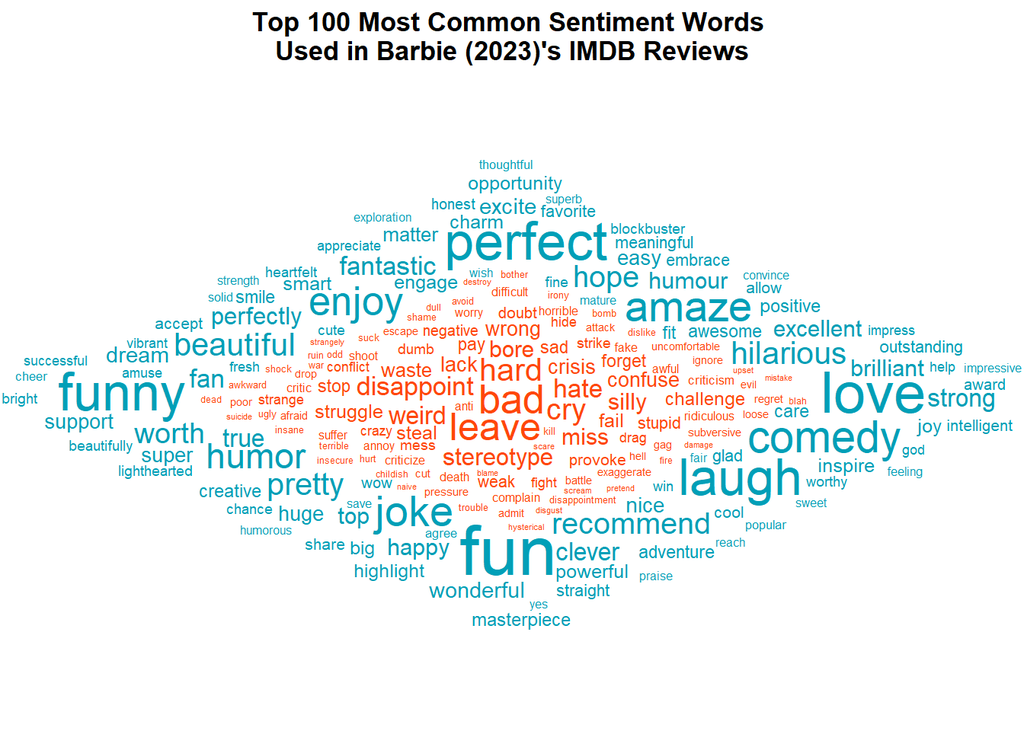

```r
 wordSent %>% group_by(sentiment) %>% slice_max(n, n = 100) %>% ungroup() %>%
        ggplot(aes(label = word, size = n, color = sentiment))+
        geom_text_wordcloud(shape = "diamond")+
        scale_color_manual(values = c("#FF470A", "#009FB7"))+
        scale_size_area(max_size = 12)+
        theme_void()+
        theme(plot.title = element_text(hjust = .5, face = "bold"))+
  labs(title = "Top 100 Most Common Sentiment Words \nUsed in Barbie (2023)'s IMDB Reviews")
```

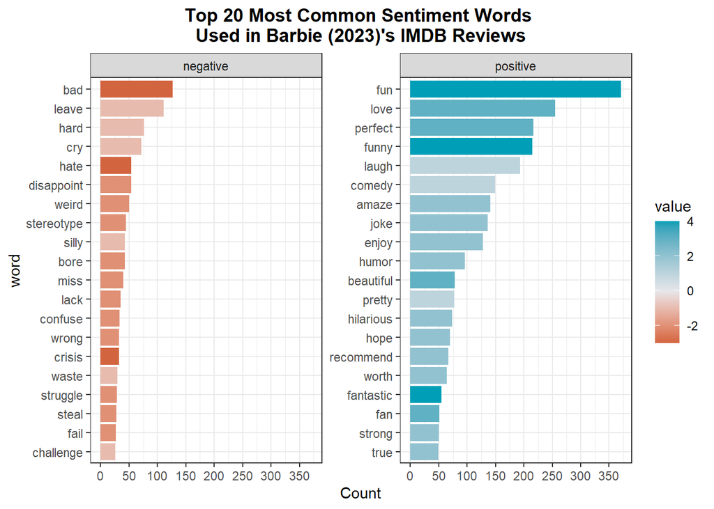

```r
wordSent %>% group_by(sentiment) %>% slice_max(n, n = 20) %>% ungroup() %>% mutate(word = reorder(word,n)) %>%
  ggplot(., aes(n, word, fill = value))+
  geom_col()+
  scale_fill_gradient2(position="bottom" ,
                       low = "#BF3100",
                       mid = "#E6E6EA",
                       high = "#009FB7")+
  facet_wrap(~sentiment, scales = "free_y")+
  scale_x_continuous(name = "Count", breaks = pretty_breaks(n = 10))+
  theme_bw()+
  theme(plot.title = element_text(hjust = .5, face = "bold"))+
  labs(title = "Top 20 Most Common Sentiment Words \nUsed in Barbie (2023)'s IMDB Reviews")
```

##### Bi-Gram Sentiment

For bi-gram I used the Valence Aware Dictionary for Sentiment Reasoning (VADER) library since it’s the only one that support more than one word. Similar preparation to word.

```r
vader_allbigrams <- fst::read_fst("vader_allbigrams.fst")
vaderbigrams <- rename(vader_allbigrams, bigram = text)

sentiment_vader <- inner_join(bigram_counts, vaderbigrams, by = c("word12" = "bigram"))
sentiment_noNeutral <- sentiment_vader %>% filter(neu != 1) #Filter pure neutral bigrams

sentiment_noNeutral$sentiment <- ifelse(sentiment_noNeutral$compound > 0, "positive", "negative") #Code sentiment
```

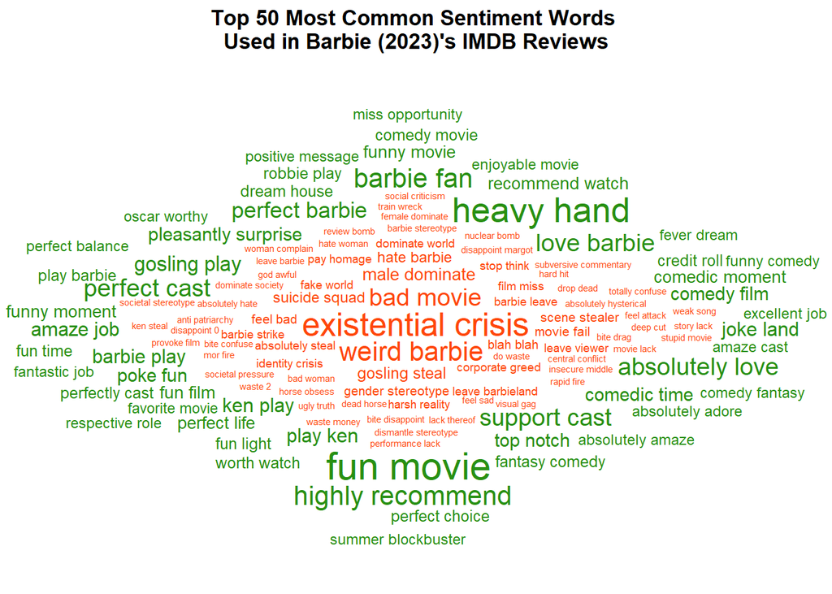

```r
sentiment_noNeutral %>% group_by(sentiment) %>% slice_max(n, n = 50) %>% ungroup() %>%
        ggplot(aes(label = word12, size = n, color = sentiment))+
        geom_text_wordcloud(shape = "diamond")+
        scale_color_manual(values = c("#FF470A", "#289013"))+
        scale_size_area(max_size = 8)+
        theme_void()+
        theme(plot.title = element_text(hjust = .5, face = "bold"))+
  labs(title = "Top 50 Most Common Sentiment Words \nUsed in Barbie (2023)'s IMDB Reviews")
```

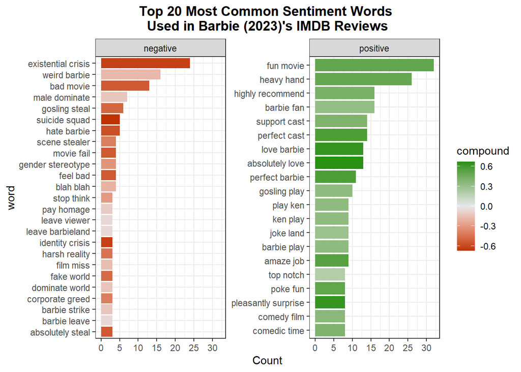

```r
sentiment_noNeutral %>% group_by(sentiment) %>% slice_max(n, n = 20) %>% ungroup() %>% mutate(word = reorder(word12,n)) %>%
  ggplot(., aes(n, word, fill = compound))+
  geom_col()+
  scale_fill_gradient2(position="bottom" ,
                       low = "#BF3100",
                       mid = "#E6E6EA",
                       high = "#289013")+
  facet_wrap(~sentiment, scales = "free_y")+
  scale_x_continuous(name = "Count", breaks = pretty_breaks(n = 10))+
  theme_bw()+
  theme(plot.title = element_text(hjust = .5, face = "bold"))+
  labs(title = "Top 20 Most Common Sentiment Words \nUsed in Barbie (2023)'s IMDB Reviews")
```

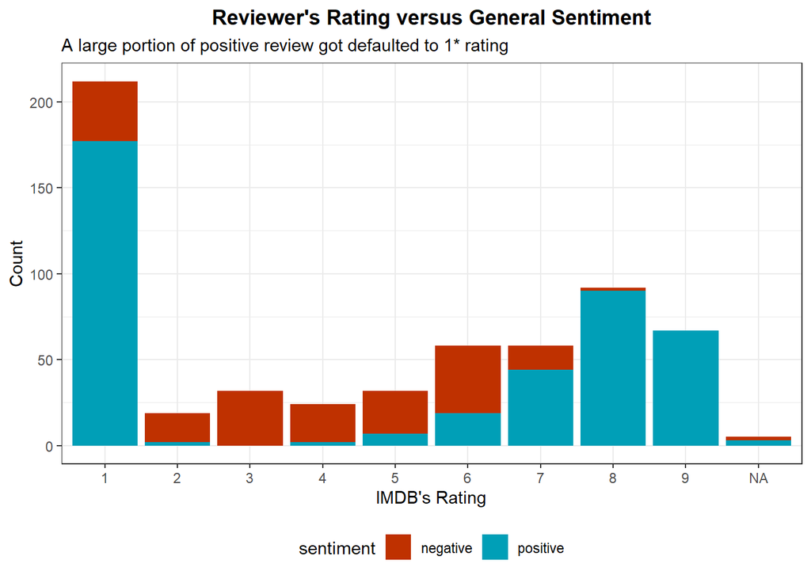

```r
review_sentiment <- fst::read_fst("reviewSentiment.fst") #Load data since I add sentiment manually

#Redo all cleaning since I didn't want to messsed up past codes
forRev <- dat %>% filter(!grepl("Warning: Spoilers", text))
forRev$review <- sub('.*July 2023', '', forRev$text)
forRev <- forRev %>% subset(select = -c(text, thesis))

review_analysis <- full_join(forRev, review_sentiment, by = c("ID", "review")) #Join back with the other dataset to get date and rating
review_analysis <- review_analysis %>%  filter(!is.na(sentiment)) #There was one review with no review so I removed it

review_analysis$date[review_analysis$ID == 549] <- "2023-07-21" #Fix a bugged date

review_analysis$date <- as.Date(review_analysis$date) #Convert to date to remove the time (not in the original dataset)

ggplot(review_analysis, aes(as.factor(rating), fill = sentiment))+
      geom_bar()+
      theme_bw()+
      scale_fill_manual(values = c("#BF3100", "#009FB7"))+
      theme(plot.title = element_text(face = "bold", hjust = .5),
            legend.position = "bottom",)+
      scale_x_discrete(name = "IMDB's Rating")+
      scale_y_continuous(name = "Count")+
      labs(title = "Reviewer's Rating versus General Sentiment",
           subtitle = "A large portion of positive review got defaulted to 1* rating")
```

```r
sentCountDate <- review_analysis %>% group_by(sentiment, date) %>% summarise(n = n()) #Get count of sentiment over the premiere week
```

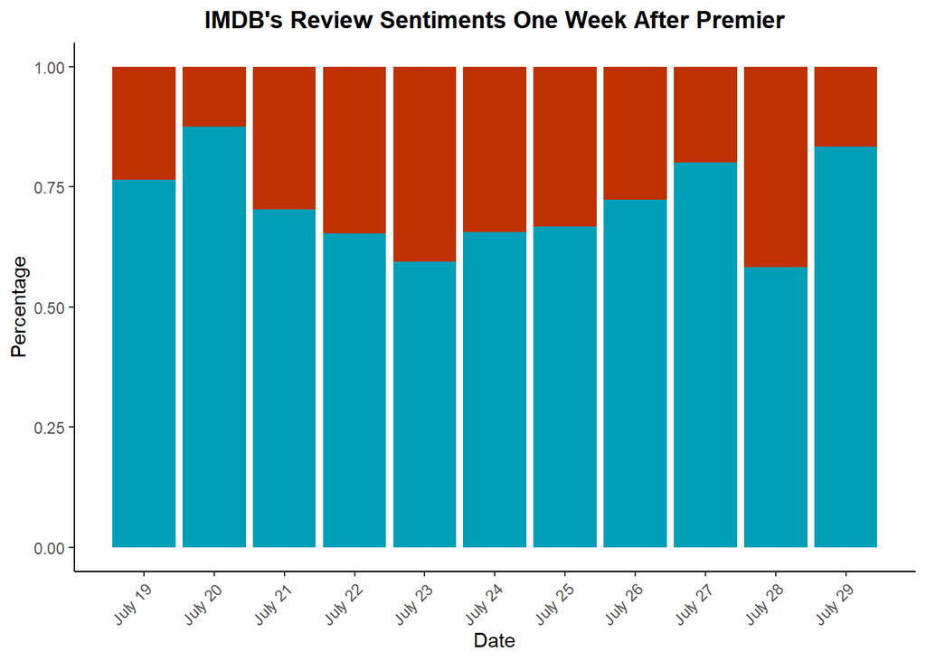

```r
sentSumCount <- review_analysis %>% group_by(date) %>% summarise(n = n()) #Get total review per date

sentComb <- left_join(sentCountDate, sentSumCount, by = "date") #Join two datasets together to calculate percentage
sentComb$perc <- sentComb$n.x/sentComb$n.y #Calculate percentage
sentComb$perc_lab <- percent(sentComb$perc) #Create percentage label that I did not use

 ggplot(sentComb ,aes(date, perc, fill = sentiment))+
      geom_col()+
      scale_fill_manual(values = c("#BF3100", "#009FB7"))+
      theme_classic()+
      scale_x_date(name = "Date", date_breaks = "1 day", date_labels = "%B %d")+
      theme(axis.text.x = element_text(angle = 45, hjust = 1),
            legend.position = "none",
            plot.title = element_text(face = "bold", hjust = .5))+
      scale_y_continuous(name = "Percentage")+
      labs(title = "IMDB's Review Sentiments One Week After Premier")
```

#### *Topic Modeling*

For topic modeling (clustering for text mining), I used LDA with Gibbs methods, k is set at 4 due to diminishing return at a higher value. The results exceeded my expectations. In order, topic 1 focuses on the women empowering theme of the movie, topic 2 focuses on the great performance of the lead actors as well as the director, topic 3 focuses on the summary of the movie, and topic 4 focuses on the fact that this is a good movie. From the beta value, we see that most reviews emphasize the humorous nature of the movie as well as the talented Greta Gerwig, Margot Robbie, and Ryan Gosling.

```r
#Converting dataset to dtm format
dtm_review <- tidyDat %>%
  count(ID, word) %>%
  cast_dtm(ID, word, n) %>%
  as.matrix()

lda_topics <- LDA(dtm_review, k = 4, method = "Gibbs", control = list(seed = 123)) %>%
  tidy(matrix = "beta") #Applying LDA

word_probs <- lda_topics %>% group_by(topic) %>%
  top_n(15,beta) %>%
  ungroup() %>%
  mutate(term = fct_reorder(term, beta)) #Convert back to data.frame
```

[figure not shown]

```r
ggplot(word_probs, aes(term, beta, fill = as.factor(topic)))+
      geom_col()+
      facet_wrap(~topic, scales = "free_y")+
      coord_flip()+
      theme_classic()+
      theme(legend.position = "none",
            plot.title = element_text(face = "bold", hjust = .5))+
  labs(title = "Topic Modeling")
```

### **Recommendation**

As indicated by the presentation, it’s evident that this movie holds substantial appeal, leading audiences to overlook a number of its shortcomings, as evident from the significantly positive reception on IMDb. Such large-scale productions are often subject to the influences of numerous stakeholders, which can sometimes hinder their creative coherence. Consequently, the decision by Mattel to allocate resources to the development of its proprietary toy universe may not be the most strategic course of action.

Instead of channeling efforts into expanding a separate toy universe, Mattel would likely benefit more from concentrating on the creation of compelling movies with robust and resonant themes. Allocating resources to crafting narratives that captivate and engage audiences can yield a more profound and sustainable impact.

Furthermore, it’s worth highlighting the pivotal role that skilled actors play in enhancing a film’s overall quality. As echoed in numerous 5-6 star reviews, adept performances can substantially elevate the cinematic experience. Investing in talent that can effectively embody characters and convey emotions not only enriches the narrative but also leaves a lasting impression on the audience. This resonates with viewers and contributes to the film’s resonance and enduring popularity.

In conclusion, the movie’s undeniable allure, despite its imperfections, emphasizes the potential for creating impactful films. Rather than dispersing efforts into ventures outside its core competency, Mattel should channel its resources into producing movies that resonate deeply with audiences. By emphasizing strong storytelling and leveraging the influence of skilled actors, the company can establish a more lasting and influential presence in the film industry. This strategic shift will likely yield greater dividends in both artistic acclaim and commercial success compared to diverting resources to an isolated toy universe venture.

### **3Ws**

#### *What Went Well?*

I was surprised that the Barbie project went as well as it did. As mentioned in the presentation, I spent probably 15-20 hours on other datasets before settling on this one and so I was at a heavy time disadvantage when starting this project. I would like to dedicate my deepest thanks to all the people that develop text analysis libraries used in this project.

The dashboard also went surprisingly well. The process is a lot smoother after having a solid understanding of the structure of Shiny. Additionally, I learned how to cache my plots which helped load time tremendously. We web design now!

Lastly, clustering in text mining is surprisingly easy to interpret compared to data mining. I guess it’s due to the nature of the brain to find patterns and project meanings to them.

#### *What did not Go Well?*

While the sunk cost from spending time in other projects was immense. I did learn a lot so I’m not too upset about that. Most of my problems was in troubleshooting not working functions. It makes me realize that it is one of the bigger setback of open-source tools such as this one. Compatibility can breaks easily.

The most challenging aspect of this project, in my perspective, was dealing with regex. R employs distinct syntax for regular expressions, rendering commonly used tools ineffective. Coupled with sparse documentation, the learning process proved to be a source of frustration.

#### *What Would I Do Differently?*

Given more time, I would spend time learning to scrape review data from movies such as Oppenheimer and Greta Gerwig’s past work. Additionally, I would also like to compare review from IMDb to Rotten Tomatoes even the script of the movie itself.

Once I get better at regex, I will be able to do more with text parsing as well.